# PERSONAL LOAN CAMPAIGN PROJECT

## Personal Loan Campaign - Problem Statement

### Description

#### Background and Context

- AllLife Bank is a US bank that has a growing customer base. The majority of these customers are liability customers (depositors) with varying sizes of deposits. The number of customers who are also borrowers (asset customers) is quite small, and the bank is interested in expanding this base rapidly to bring in more loan business and in the process, earn more through the interest on loans. In particular, the management wants to explore ways of converting its liability customers to personal loan customers (while retaining them as depositors).
- A campaign that the bank ran last year for liability customers showed a healthy conversion rate of over 9% success. This has encouraged the retail marketing department to devise campaigns with better target marketing to increase the success ratio.
- You as a Data scientist at AllLife bank have to build a model that will help the marketing department to identify the potential customers who have a higher probability of purchasing the loan.

#### Objective

1. To predict whether a liability customer will buy a personal loan or not.
2. Which variables are most significant.
3. Which segment of customers should be targeted more.

#### Data Dictionary

- ID: Customer ID
- Age: Customer’s age in completed years
- Experience: #years of professional experience
- Income: Annual income of the customer (in thousand dollars)
- ZIP Code: Home Address ZIP code.
- Family: the Family size of the customer
- CCAvg: Average spending on credit cards per month (in thousand dollars)
- Education: Education Level. 1: Undergrad; 2: Graduate;3: Advanced/Professional
- Mortgage: Value of house mortgage if any. (in thousand dollars)
- Personal_Loan: Did this customer accept the personal loan offered in the last campaign?
- Securities_Account: Does the customer have securities account with the bank?
- CD_Account: Does the customer have a certificate of deposit (CD) account with the bank?
- Online: Do customers use internet banking facilities?
- CreditCard: Does the customer use a credit card issued by any other Bank (excluding All life Bank)?

```python
# Let's import relevant libraries


# this will help in making the Python code more structured automatically
%load_ext nb_black

# Libraries to help with reading and manipulating data
import pandas as pd
import numpy as np

# Libraries to help with data visualization
import matplotlib.pyplot as plt

%matplotlib inline
import seaborn as sns

sns.set(color_codes=True)

pd.set_option(
    "display.max_columns", None
)  # Removes the limit for the number of displayed columns
pd.set_option(
    "display.max_rows", 200
)  # Sets the limit for the number of displayed rows

# To explore the zipcode column
from uszipcode import SearchEngine

# To deep copy the dataset for later use
import copy

from sklearn.model_selection import (
    train_test_split,
)  # to split the data into train and test

from sklearn.linear_model import (
    LogisticRegression,
)  # to build logistic regression_model

# to build decision tree
from sklearn.tree import DecisionTreeClassifier
from sklearn import tree

# to check model performance
from sklearn import metrics
from sklearn.metrics import (
    accuracy_score,
    recall_score,
    precision_score,
    roc_auc_score,
    roc_curve,
    confusion_matrix,
    precision_recall_curve,
    f1_score,
)
from sklearn.model_selection import GridSearchCV


# To filter warnings
import warnings

warnings.filterwarnings("ignore")
```

```python
# Let's read the dataset to work with
data = pd.read_csv("Loan_Modelling.csv")
data.head()  # To see the first 5 rows in the dataset
```

|  | ID | Age | Experience | Income | ZIPCode | Family | CCAvg | Education | Mortgage | Personal_Loan | Securities_Account | CD_Account | Online | CreditCard |
| --- | --- | --- | --- | --- | --- | --- | --- | --- | --- | --- | --- | --- | --- | --- |
| 0 | 1 | 25 | 1 | 49 | 91107 | 4 | 1.6 | 1 | 0 | 0 | 1 | 0 | 0 | 0 |
| 1 | 2 | 45 | 19 | 34 | 90089 | 3 | 1.5 | 1 | 0 | 0 | 1 | 0 | 0 | 0 |
| 2 | 3 | 39 | 15 | 11 | 94720 | 1 | 1.0 | 1 | 0 | 0 | 0 | 0 | 0 | 0 |
| 3 | 4 | 35 | 9 | 100 | 94112 | 1 | 2.7 | 2 | 0 | 0 | 0 | 0 | 0 | 0 |
| 4 | 5 | 35 | 8 | 45 | 91330 | 4 | 1.0 | 2 | 0 | 0 | 0 | 0 | 0 | 1 |

#### Observation: The dataset looks consistent with the description provided in the Data Dictionary.

```python
df = data.copy()  # To keep a copy of the original data set
```

```python
df.sample(20)  # to sample 20 rows in the dataset
```

|  | ID | Age | Experience | Income | ZIPCode | Family | CCAvg | Education | Mortgage | Personal_Loan | Securities_Account | CD_Account | Online | CreditCard |
| --- | --- | --- | --- | --- | --- | --- | --- | --- | --- | --- | --- | --- | --- | --- |
| 2772 | 2773 | 55 | 31 | 130 | 92646 | 4 | 6.5 | 1 | 0 | 1 | 0 | 0 | 0 | 1 |
| 4569 | 4570 | 47 | 21 | 49 | 92152 | 3 | 2.2 | 2 | 0 | 0 | 1 | 0 | 0 | 0 |
| 623 | 624 | 44 | 19 | 34 | 95616 | 1 | 0.3 | 3 | 78 | 0 | 0 | 0 | 1 | 0 |
| 4941 | 4942 | 28 | 4 | 112 | 90049 | 2 | 1.6 | 2 | 0 | 1 | 0 | 0 | 1 | 0 |
| 4204 | 4205 | 40 | 16 | 61 | 91711 | 3 | 2.1 | 3 | 0 | 0 | 0 | 0 | 0 | 0 |
| 279 | 280 | 39 | 14 | 155 | 94577 | 2 | 3.9 | 1 | 0 | 0 | 0 | 0 | 1 | 0 |
| 2678 | 2679 | 63 | 38 | 148 | 93023 | 2 | 4.3 | 3 | 0 | 1 | 0 | 0 | 1 | 0 |
| 2252 | 2253 | 58 | 32 | 41 | 95819 | 3 | 1.4 | 1 | 0 | 0 | 0 | 0 | 1 | 0 |
| 3884 | 3885 | 27 | 1 | 112 | 91330 | 4 | 2.3 | 3 | 402 | 0 | 0 | 0 | 1 | 1 |
| 4541 | 4542 | 62 | 38 | 124 | 95023 | 1 | 3.8 | 1 | 405 | 0 | 0 | 0 | 1 | 0 |
| 678 | 679 | 52 | 27 | 61 | 92101 | 4 | 1.8 | 3 | 207 | 0 | 0 | 0 | 0 | 0 |
| 4068 | 4069 | 59 | 34 | 21 | 95035 | 2 | 0.5 | 2 | 0 | 0 | 0 | 0 | 1 | 0 |
| 2575 | 2576 | 42 | 16 | 41 | 90401 | 3 | 0.5 | 3 | 0 | 0 | 0 | 0 | 1 | 0 |
| 2602 | 2603 | 52 | 26 | 161 | 93108 | 4 | 4.3 | 1 | 0 | 1 | 0 | 1 | 1 | 1 |
| 2079 | 2080 | 26 | 2 | 40 | 94132 | 1 | 1.0 | 3 | 0 | 0 | 0 | 0 | 1 | 0 |
| 2320 | 2321 | 46 | 22 | 84 | 92692 | 4 | 2.0 | 3 | 0 | 0 | 0 | 0 | 1 | 0 |
| 781 | 782 | 56 | 32 | 158 | 94588 | 3 | 3.7 | 3 | 0 | 1 | 0 | 0 | 1 | 0 |
| 1378 | 1379 | 54 | 29 | 34 | 93305 | 4 | 0.1 | 3 | 0 | 0 | 0 | 0 | 1 | 0 |
| 4474 | 4475 | 66 | 41 | 73 | 95817 | 3 | 2.4 | 1 | 0 | 0 | 0 | 0 | 0 | 0 |
| 900 | 901 | 30 | 4 | 51 | 94709 | 4 | 0.2 | 1 | 172 | 0 | 0 | 0 | 0 | 1 |

#### Looking at the columns data, it is obvious we do not need 'ID' column at all as it contains no data relevant to the project objective. We will therefore drop it shortly

```python
df.shape  # to see the shape of the data
```

```
(5000, 14)
```

#### Observation: The dataset contains 5000 rows and 14 columns

```python
df.info()  # To print the concise summary of the data set
```

```
<class 'pandas.core.frame.DataFrame'>
RangeIndex: 5000 entries, 0 to 4999
Data columns (total 14 columns):
 #   Column              Non-Null Count  Dtype
---  ------              --------------  -----
 0   ID                  5000 non-null   int64
 1   Age                 5000 non-null   int64
 2   Experience          5000 non-null   int64
 3   Income              5000 non-null   int64
 4   ZIPCode             5000 non-null   int64
 5   Family              5000 non-null   int64
 6   CCAvg               5000 non-null   float64
 7   Education           5000 non-null   int64
 8   Mortgage            5000 non-null   int64
 9   Personal_Loan       5000 non-null   int64
 10  Securities_Account  5000 non-null   int64
 11  CD_Account          5000 non-null   int64
 12  Online              5000 non-null   int64
 13  CreditCard          5000 non-null   int64
dtypes: float64(1), int64(13)
memory usage: 547.0 KB
```

#### Observations:It appears that all the variables in the dataset are numerical and are all integers except CCAvg that contains float. However, ZIPCode here is categorical in nature from natural knowledge. Further categorical information will be extracted from Zipcode shortly. Also, from the data dictionary, Education, Personal_Loan, Securities_Account,CD_Account,Online, and CreditCard all contained categorical(classification) data. It also appears there is no missing values in the data but we will further confirm this

```python
df.duplicated().sum()  # To check if there is any duplicated row in the dataset
```

```
0
```

#### Observation: There is no duplicated row in the dataset

```python
df.columns  # To check the names of columns in the dataset properly
```

```
Index(['ID', 'Age', 'Experience', 'Income', 'ZIPCode', 'Family', 'CCAvg',
       'Education', 'Mortgage', 'Personal_Loan', 'Securities_Account',
       'CD_Account', 'Online', 'CreditCard'],
      dtype='object')
```

#### Observation: From the project objective, it is clear that the target variable is the Personal_Loan column while the rest are independent variables

```python
df.isnull().sum()  # To confirm if there are missing values in the dataset or not
```

```
ID                    0
Age                   0
Experience            0
Income                0
ZIPCode               0
Family                0
CCAvg                 0
Education             0
Mortgage              0
Personal_Loan         0
Securities_Account    0
CD_Account            0
Online                0
CreditCard            0
dtype: int64
```

#### Observation: As earlier mentioned, there is no missing value in the data set

### Let's process ZIPCode to a good shape for modelling

```python
df["ZIPCode"].value_counts()  # To check the unique values in ZIPCode column
```

```
94720    169
94305    127
95616    116
90095     71
93106     57
        ...
96145      1
94087      1
91024      1
93077      1
94598      1
Name: ZIPCode, Length: 467, dtype: int64
```

#### Observation: There are 467 unique zipcodes in the data. Zipcodes 94720, 94305, 95616 are the 3 most common in the data set

```python
# To look at the location details of the commonest zipcode in the data
search = SearchEngine()
zip_code = search.by_zipcode("94720")
zip_code
```

```
SimpleZipcode(zipcode='94720', zipcode_type='Unique', major_city='Berkeley', post_office_city='Berkeley, CA', common_city_list=['Berkeley', 'Uc Berkeley'], county='Alameda County', state='CA', lat=37.87, lng=-122.26, timezone='Pacific', radius_in_miles=0.7386363636363636, area_code_list=['510'], pop…
```

#### Observation: Customers with Zipcode 94720 lives in Alameda County of Califonia State of USA. Based on this and to reduce dimensionality of the Zipcode column, let's extract the county of each customer from their zipcode and use it to replace the zipcode column

```python
# To add a new column to the dataset containing the county of each client
df["county"] = df["ZIPCode"].map(lambda x: search.by_zipcode(x).county)
```

```python
df.sample(10)  # To sample 10 rows and confirm the county column just created
```

|  | ID | Age | Experience | Income | ZIPCode | Family | CCAvg | Education | Mortgage | Personal_Loan | Securities_Account | CD_Account | Online | CreditCard | county |
| --- | --- | --- | --- | --- | --- | --- | --- | --- | --- | --- | --- | --- | --- | --- | --- |
| 1018 | 1019 | 39 | 15 | 61 | 90018 | 2 | 0.6 | 3 | 127 | 0 | 0 | 0 | 0 | 0 | Los Angeles County |
| 2226 | 2227 | 25 | 1 | 98 | 90717 | 1 | 5.4 | 1 | 0 | 0 | 0 | 0 | 1 | 0 | Los Angeles County |
| 421 | 422 | 28 | 3 | 115 | 92333 | 4 | 3.1 | 2 | 0 | 1 | 0 | 0 | 0 | 0 | San Bernardino County |
| 3905 | 3906 | 52 | 28 | 55 | 94596 | 1 | 1.6 | 3 | 0 | 0 | 0 | 0 | 0 | 0 | Contra Costa County |
| 2582 | 2583 | 33 | 9 | 42 | 95010 | 1 | 2.1 | 3 | 0 | 0 | 0 | 0 | 1 | 0 | Santa Cruz County |
| 762 | 763 | 32 | 6 | 85 | 90504 | 1 | 2.7 | 2 | 100 | 0 | 0 | 0 | 1 | 0 | Los Angeles County |
| 3468 | 3469 | 43 | 19 | 113 | 93933 | 2 | 1.8 | 2 | 0 | 0 | 0 | 0 | 0 | 1 | Monterey County |
| 1064 | 1065 | 41 | 17 | 138 | 95008 | 3 | 6.9 | 2 | 0 | 1 | 0 | 0 | 1 | 0 | Santa Clara County |
| 4436 | 4437 | 60 | 35 | 33 | 90095 | 2 | 0.5 | 2 | 0 | 0 | 0 | 0 | 1 | 0 | Los Angeles County |
| 1932 | 1933 | 64 | 39 | 73 | 90073 | 3 | 2.4 | 1 | 185 | 0 | 0 | 0 | 0 | 0 | Los Angeles County |

```python
df.county.value_counts()  # To confirm the unique values in the county column
```

```
Los Angeles County        1095
San Diego County           568
Santa Clara County         563
Alameda County             500
Orange County              339
San Francisco County       257
San Mateo County           204
Sacramento County          184
Santa Barbara County       154
Yolo County                130
Monterey County            128
Ventura County             114
San Bernardino County      101
Contra Costa County         85
Santa Cruz County           68
Riverside County            56
Marin County                54
Kern County                 54
San Luis Obispo County      33
Solano County               33
Humboldt County             32
Sonoma County               28
Fresno County               26
Placer County               24
Butte County                19
Shasta County               18
El Dorado County            17
Stanislaus County           15
San Benito County           14
San Joaquin County          13
Mendocino County             8
Siskiyou County              7
Tuolumne County              7
Merced County                4
Trinity County               4
Lake County                  4
Imperial County              3
Napa County                  3
Name: county, dtype: int64
```

#### Observation: It is obvious now that the highest number of Alllife Bank customers lives in Los Angeles County. It is also observed that all the unique values have 'County' ending them, we will remove this string now

```python
# Let's create a function to remove the string 'County' from all county names in the county column
def county_split(col_val):
    if isinstance(col_val, str):
        if col_val.endswith("County"):
            return col_val.replace("County", "")
    else:
        return col_val


df["county"] = df["county"].apply(county_split)
```

```python
df.sample(
    10
)  # to sample 10 rows and confirm if the county column is now in order or not
```

|  | ID | Age | Experience | Income | ZIPCode | Family | CCAvg | Education | Mortgage | Personal_Loan | Securities_Account | CD_Account | Online | CreditCard | county |
| --- | --- | --- | --- | --- | --- | --- | --- | --- | --- | --- | --- | --- | --- | --- | --- |
| 2801 | 2802 | 58 | 34 | 41 | 91016 | 4 | 0.4 | 1 | 177 | 0 | 0 | 0 | 1 | 0 | Los Angeles |
| 543 | 544 | 63 | 38 | 54 | 94704 | 3 | 2.4 | 1 | 90 | 0 | 0 | 0 | 0 | 1 | Alameda |
| 664 | 665 | 54 | 30 | 64 | 95126 | 1 | 1.8 | 3 | 227 | 0 | 0 | 0 | 0 | 1 | Santa Clara |
| 4161 | 4162 | 32 | 8 | 61 | 94703 | 3 | 2.6 | 2 | 0 | 0 | 0 | 0 | 0 | 0 | Alameda |
| 2647 | 2648 | 61 | 37 | 155 | 91605 | 1 | 2.9 | 1 | 0 | 0 | 0 | 0 | 1 | 0 | Los Angeles |
| 1723 | 1724 | 39 | 15 | 55 | 95821 | 1 | 1.5 | 3 | 0 | 0 | 0 | 0 | 1 | 0 | Sacramento |
| 3281 | 3282 | 51 | 25 | 62 | 95014 | 2 | 1.5 | 2 | 0 | 0 | 0 | 0 | 1 | 1 | Santa Clara |
| 414 | 415 | 52 | 28 | 41 | 94309 | 3 | 1.9 | 2 | 0 | 0 | 0 | 0 | 0 | 1 | Santa Clara |
| 1545 | 1546 | 55 | 29 | 131 | 92675 | 2 | 2.7 | 1 | 0 | 0 | 1 | 0 | 0 | 0 | Orange |
| 4761 | 4762 | 61 | 35 | 74 | 91320 | 2 | 0.7 | 2 | 0 | 0 | 0 | 0 | 1 | 1 | Ventura |

#### Observation: The word 'County' has now been removed from all the county names in the county column

```python
df.drop(
    ["ID", "ZIPCode"], axis=1, inplace=True
)  # To drop 'ID' and 'ZIPCode' columns from the dataset
```

```python
df_new = copy.deepcopy(df)  # To deepcopy the dataframe for later use
```

```python
df[
    df["county"].isnull()
]  # Let's check if there is any missingness in the county column created
```

|  | Age | Experience | Income | Family | CCAvg | Education | Mortgage | Personal_Loan | Securities_Account | CD_Account | Online | CreditCard | county |
| --- | --- | --- | --- | --- | --- | --- | --- | --- | --- | --- | --- | --- | --- |
| 106 | 43 | 17 | 69 | 4 | 2.90 | 1 | 0 | 0 | 0 | 0 | 1 | 1 | None |
| 172 | 38 | 13 | 171 | 2 | 7.80 | 1 | 0 | 0 | 0 | 0 | 1 | 0 | None |
| 184 | 52 | 26 | 63 | 2 | 1.50 | 2 | 0 | 0 | 1 | 0 | 1 | 0 | None |
| 321 | 44 | 20 | 101 | 3 | 4.40 | 2 | 82 | 1 | 0 | 0 | 0 | 0 | None |
| 366 | 50 | 24 | 35 | 1 | 0.30 | 3 | 0 | 0 | 0 | 0 | 1 | 0 | None |
| 384 | 51 | 25 | 21 | 4 | 0.60 | 3 | 0 | 0 | 0 | 0 | 1 | 1 | None |
| 468 | 34 | 10 | 21 | 1 | 0.50 | 3 | 0 | 0 | 0 | 0 | 1 | 0 | None |
| 476 | 60 | 34 | 53 | 1 | 0.80 | 2 | 0 | 0 | 1 | 0 | 0 | 1 | None |
| 630 | 32 | 7 | 35 | 3 | 1.30 | 1 | 108 | 0 | 0 | 0 | 0 | 1 | None |
| 672 | 51 | 27 | 23 | 1 | 0.20 | 1 | 0 | 0 | 0 | 0 | 1 | 0 | None |
| 695 | 29 | 4 | 115 | 1 | 1.90 | 1 | 0 | 0 | 0 | 0 | 0 | 0 | None |
| 721 | 49 | 24 | 39 | 1 | 1.40 | 3 | 0 | 0 | 0 | 0 | 1 | 0 | None |
| 780 | 32 | 7 | 42 | 4 | 0.80 | 1 | 0 | 0 | 0 | 0 | 1 | 1 | None |
| 1099 | 30 | 6 | 52 | 3 | 0.70 | 2 | 0 | 0 | 0 | 0 | 1 | 0 | None |
| 1189 | 42 | 17 | 115 | 2 | 0.40 | 1 | 0 | 0 | 0 | 0 | 1 | 0 | None |
| 1426 | 37 | 11 | 60 | 3 | 0.50 | 3 | 0 | 0 | 0 | 0 | 1 | 0 | None |
| 1483 | 58 | 32 | 63 | 1 | 1.60 | 1 | 0 | 0 | 1 | 0 | 1 | 0 | None |
| 1653 | 26 | 1 | 24 | 2 | 0.90 | 3 | 123 | 0 | 0 | 0 | 0 | 1 | None |
| 1752 | 33 | 8 | 155 | 1 | 7.40 | 3 | 0 | 1 | 0 | 0 | 0 | 0 | None |
| 1844 | 65 | 40 | 21 | 3 | 0.10 | 3 | 0 | 0 | 0 | 0 | 0 | 1 | None |
| 2049 | 43 | 18 | 94 | 4 | 1.10 | 2 | 0 | 0 | 0 | 0 | 1 | 0 | None |
| 2211 | 39 | 14 | 31 | 2 | 1.40 | 2 | 94 | 0 | 0 | 0 | 1 | 1 | None |
| 2218 | 38 | 13 | 9 | 2 | 0.30 | 2 | 0 | 0 | 0 | 0 | 0 | 0 | None |
| 2428 | 39 | 12 | 108 | 4 | 3.67 | 2 | 301 | 1 | 0 | 0 | 0 | 1 | None |
| 2486 | 61 | 36 | 130 | 1 | 1.30 | 1 | 257 | 0 | 0 | 0 | 0 | 0 | None |
| 2731 | 29 | 5 | 28 | 1 | 0.20 | 3 | 0 | 0 | 0 | 0 | 1 | 0 | None |
| 2957 | 61 | 36 | 53 | 3 | 0.50 | 2 | 0 | 0 | 0 | 0 | 1 | 0 | None |
| 3525 | 59 | 34 | 13 | 4 | 0.90 | 2 | 0 | 0 | 0 | 0 | 0 | 0 | None |
| 3887 | 24 | -2 | 118 | 2 | 7.20 | 1 | 0 | 0 | 1 | 0 | 1 | 0 | None |
| 4090 | 42 | 18 | 49 | 3 | 2.10 | 3 | 0 | 0 | 1 | 0 | 1 | 0 | None |
| 4276 | 50 | 24 | 155 | 1 | 7.30 | 1 | 0 | 0 | 0 | 0 | 1 | 1 | None |
| 4321 | 27 | 0 | 34 | 1 | 2.00 | 2 | 112 | 0 | 0 | 0 | 0 | 1 | None |
| 4384 | 45 | 20 | 61 | 3 | 2.70 | 2 | 0 | 0 | 0 | 0 | 0 | 1 | None |
| 4392 | 52 | 27 | 81 | 4 | 3.80 | 2 | 0 | 0 | 0 | 0 | 0 | 0 | None |

#### Observation: It is observed now that some customers' zipcodes does not contain their counties. We will replace this with 'Unknown' for easier identification

```python
df["county"] = (
    df["county"].astype(str).replace("None", "Unknown").astype("category")
)  # To replace 'None' with 'Unknown' in the county column
```

```python
df.isnull().sum()  # To check if there remains any missingness in the data set
```

```
Age                   0
Experience            0
Income                0
Family                0
CCAvg                 0
Education             0
Mortgage              0
Personal_Loan         0
Securities_Account    0
CD_Account            0
Online                0
CreditCard            0
county                0
dtype: int64
```

#### Observation: There is no missing values in the county column nor in the entire dataset now

```python
len(
    df["county"].value_counts()
)  # To check the number of unique values in the county column and compare it with the zipcode earlier checked
```

```
39
```

#### Observation: There are 39 unique values in the county column as against the 467 in the ZIPCode column earlier checked. This means that the dimensionality of that column has been reduced from 467 to 39

```python
df.describe(include="all").T  # To get a concise statistical summary of the dataset
```

|  | count | unique | top | freq | mean | std | min | 25% | 50% | 75% | max |
| --- | --- | --- | --- | --- | --- | --- | --- | --- | --- | --- | --- |
| Age | 5000.0 | NaN | NaN | NaN | 45.3384 | 11.463166 | 23.0 | 35.0 | 45.0 | 55.0 | 67.0 |
| Experience | 5000.0 | NaN | NaN | NaN | 20.1046 | 11.467954 | -3.0 | 10.0 | 20.0 | 30.0 | 43.0 |
| Income | 5000.0 | NaN | NaN | NaN | 73.7742 | 46.033729 | 8.0 | 39.0 | 64.0 | 98.0 | 224.0 |
| Family | 5000.0 | NaN | NaN | NaN | 2.3964 | 1.147663 | 1.0 | 1.0 | 2.0 | 3.0 | 4.0 |
| CCAvg | 5000.0 | NaN | NaN | NaN | 1.937938 | 1.747659 | 0.0 | 0.7 | 1.5 | 2.5 | 10.0 |
| Education | 5000.0 | NaN | NaN | NaN | 1.881 | 0.839869 | 1.0 | 1.0 | 2.0 | 3.0 | 3.0 |
| Mortgage | 5000.0 | NaN | NaN | NaN | 56.4988 | 101.713802 | 0.0 | 0.0 | 0.0 | 101.0 | 635.0 |
| Personal_Loan | 5000.0 | NaN | NaN | NaN | 0.096 | 0.294621 | 0.0 | 0.0 | 0.0 | 0.0 | 1.0 |
| Securities_Account | 5000.0 | NaN | NaN | NaN | 0.1044 | 0.305809 | 0.0 | 0.0 | 0.0 | 0.0 | 1.0 |
| CD_Account | 5000.0 | NaN | NaN | NaN | 0.0604 | 0.23825 | 0.0 | 0.0 | 0.0 | 0.0 | 1.0 |
| Online | 5000.0 | NaN | NaN | NaN | 0.5968 | 0.490589 | 0.0 | 0.0 | 1.0 | 1.0 | 1.0 |
| CreditCard | 5000.0 | NaN | NaN | NaN | 0.294 | 0.455637 | 0.0 | 0.0 | 0.0 | 1.0 | 1.0 |
| county | 5000 | 39 | Los Angeles | 1095 | NaN | NaN | NaN | NaN | NaN | NaN | NaN |

#### Observations: The mean age of the customers is 45 years with the oldest customer aging 67 years. There are observed skewness in the Income, CCAvg and Mortgage data as there are their respective Means are far apart from their Median(50th Percentile). This will be further explored later in this project

## Univariate Analysis

### Let's visualise each variable to extract meaningful insights

```python
# Function to create both boxplot and histogram that will contain both mean and median values of applicable variables.
def hist_boxplt(feature, figsize=(15, 10), bins=None):
    sns.set(font_scale=2)
    f2, (ax_box2, ax_hist2) = plt.subplots(
        nrows=2,
        sharex=True,
        gridspec_kw={"height_ratios": (0.25, 0.75)},
        figsize=figsize,
    )
    sns.boxplot(feature, ax=ax_box2, showmeans=True, color="red")
    sns.distplot(feature, kde=True, ax=ax_hist2, bins=bins) if bins else sns.distplot(
        feature, kde=True, ax=ax_hist2
    )
    ax_hist2.axvline(np.mean(feature), color="g", linestyle="--")
    ax_hist2.axvline(np.median(feature), color="black", linestyle="-")


# Function to create barplots that indicate percentage for each category.
def perc_on_bar(feature):
    total = len(feature)  # length of the column
    plt.figure(figsize=(15, 5))
    ax = sns.countplot(feature, palette="Paired")
    for p in ax.patches:
        percentage = "{:.1f}%".format(
            100 * p.get_height() / total
        )  # to show percentage of each class of the category
        x = p.get_x() + p.get_width() / 2 - 0.05  # defining width of the plot
        y = p.get_y() + p.get_height()  # defining the height of the plot

        ax.annotate(percentage, (x, y), size=15)  # to annotate the percantage
    plt.show()  # to show the plot
```

### Age

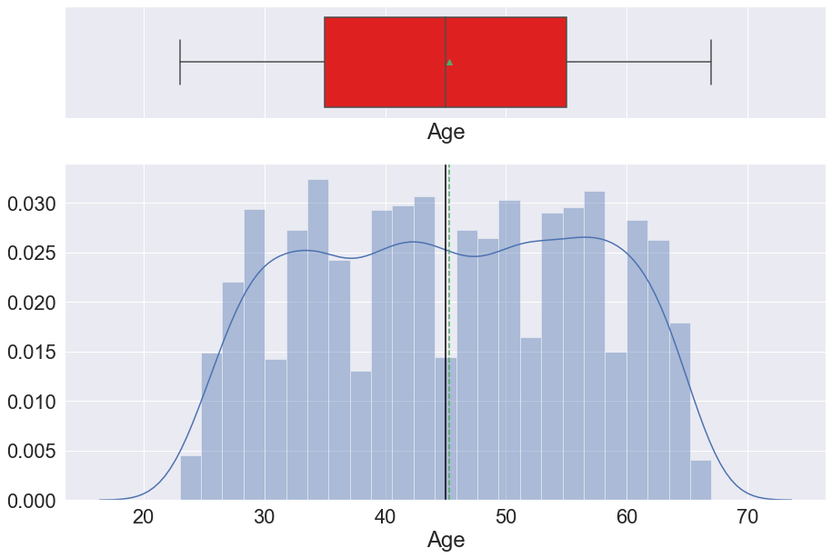

```python
hist_boxplt(df.Age, bins=25)  # to plot the boxplot and histogram of Age
```

#### Observation: Age distribution is very close to normal

### Experience

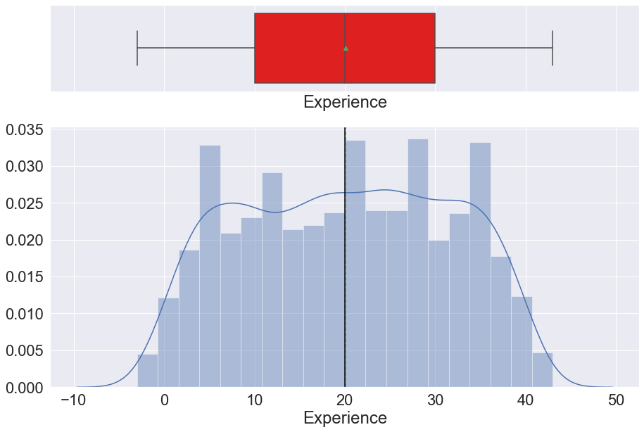

```python
hist_boxplt(df.Experience)  # to plot the boxplot and histogram of Experience
```

#### Observation: The distribution of years of Experience of the customers also is normally distributed

### Income

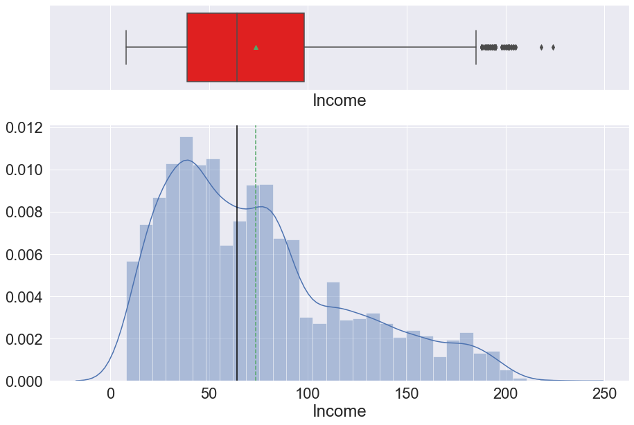

```python
hist_boxplt(df.Income)  # to plot the boxplot and histogram of Income
```

#### Observation:Bulk of the Alllife Bank customers earn income of USD150,000 and below with few customers earning more. Therefore the income distribution is right-skewed. The boxplot also revealed that 75% of the customers earn below USD100,000 with few outliers to the right

### Family

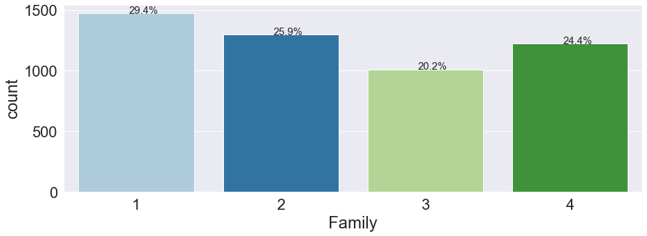

```python
perc_on_bar(df.Family)
# to create barplot of family
```

#### Observation: 29.4% of the customers have 1 as their family size. This may mean that they are mostly Singles. Also customers with family size 3 are the least in the customer base of the bank

### CCAvg

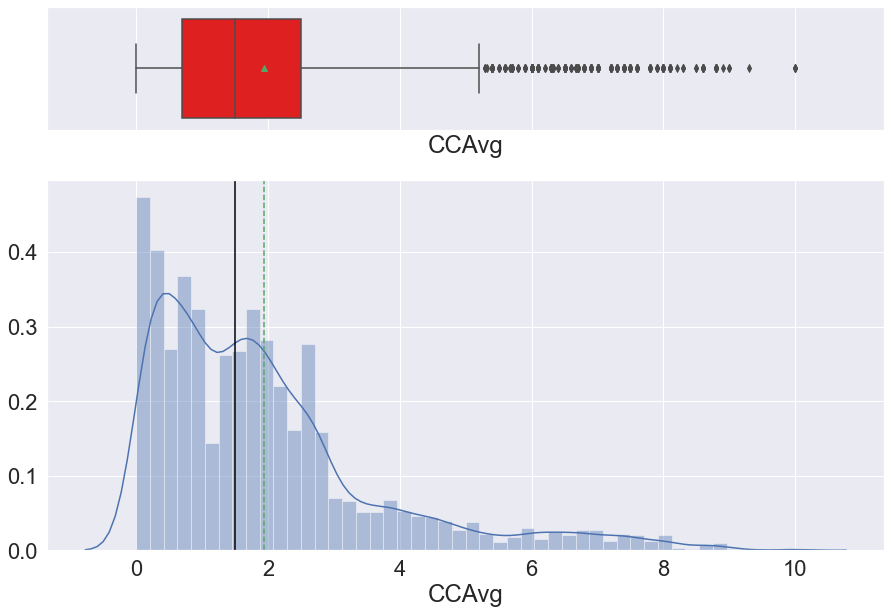

```python
hist_boxplt(df.CCAvg)  # to plot the boxplot and histogram of CCAvg
```

#### Observation: 75% of the customers spend average of USD2,500 on credit cards monthly. However, in general most customers spend USD5,000 monthly with some outliers to the right. This confirms that the CCAvg distribution is right-skewed

### Education

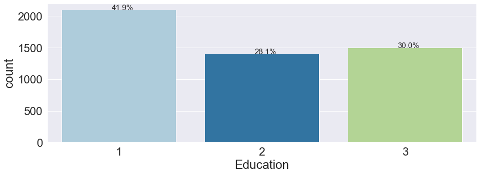

```python
perc_on_bar(df.Education)
# to create barplot of Education
```

#### Observation: 41.9% of the bank's customers are Undergraduates while 28.1% are Graduates

### Mortgage

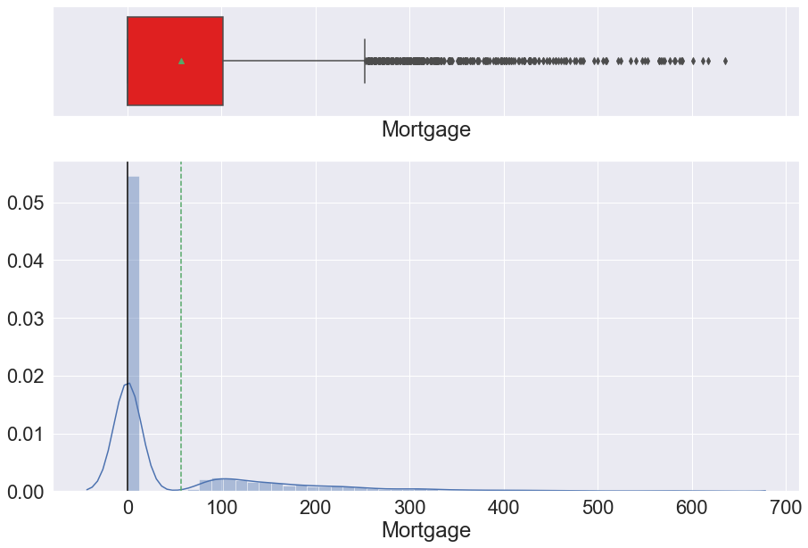

```python
hist_boxplt(df.Mortgage)  # to plot the boxplot and histogram of Mortgage
```

#### Observation:At least 50% of the bank's customers have no house mortgage. About 75% of the bank's customers have house mortgage of USD100,000. However there are some customers with very high house mortgage. The mortgage distribution is highly skewed to the right

### Personal_Loan

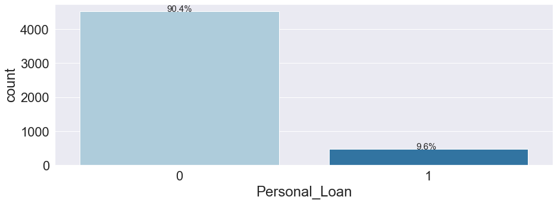

```python
perc_on_bar(df.Personal_Loan)
# to create barplot of Personal_Loan
```

#### Observation: 90.4% of the customers are not on personal loan with the bank, only 9.6% did. This is in line with the project background earlier provided

### Securities_Account

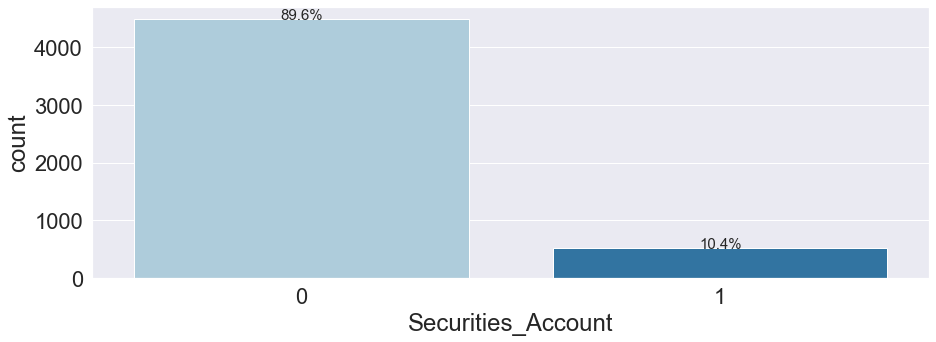

```python
perc_on_bar(df.Securities_Account)
# to create barplot of Securities_Account
```

#### Observation: Most of the bank's customers do not have securities account with the bank, only 10.4% did

### CD_Account

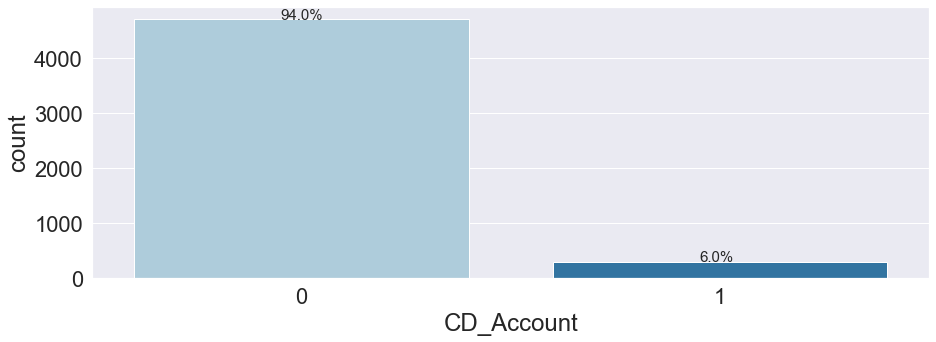

```python
perc_on_bar(df.CD_Account)
# to create barplot of CD_Account
```

#### Observation: Most of the bank's customers do not have certificate of deposit account with the bank, only 6.0% did

### Online

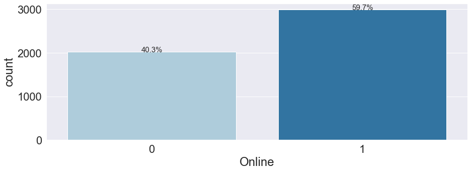

```python
perc_on_bar(df.Online)
# to create barplot of Online
```

#### Observation: 59.7% of the customers enjoy internet banking facilities while 40.3% does not.

### CreditCard

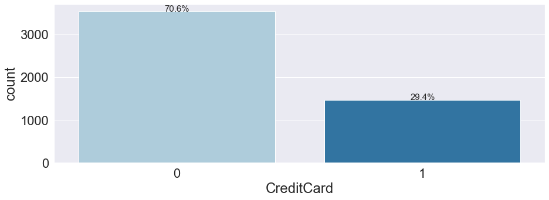

```python
perc_on_bar(df.CreditCard)
# to create barplot of CreditCard
```

#### Observation: 70.6% of the bank's customers do not have any other bank's credit card, only 29.4% do

### County

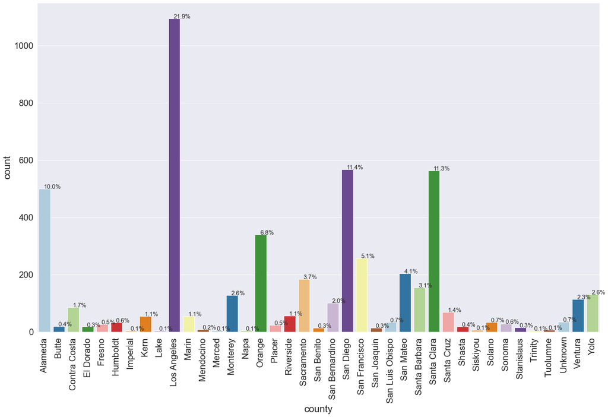

```python
# To plot a barplot of the customer's county
plt.figure(figsize=(25, 15))
plt.xticks(rotation=90)
total = len(df.county)
ax = sns.countplot(df.county, palette="Paired")
for p in ax.patches:
    percentage = "{:.1f}%".format(
        100 * p.get_height() / total
    )  # percentage of each class of the category
    x = p.get_x() + p.get_width() / 2 - 0.05  # width of the plot
    y = p.get_y() + p.get_height()  # hieght of the plot
    ax.annotate(percentage, (x, y), size=15)  # annotate the percantage
plt.show()
```

#### Observation: More than half of the bank's customers live in 4 counties: Los Angeles, San Diego, Santa Clara, and Alameda. However, most of the customers(21.9%) live in Los Angeles county

## Bivariate Analysis

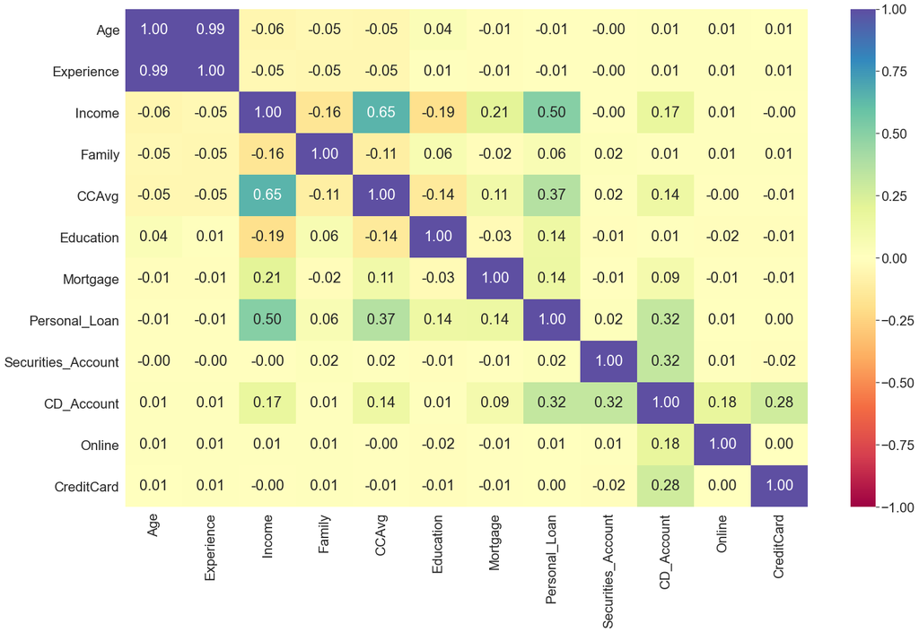

```python
# we shall plot the heatmap of the correlation ratio among the numerical data
plt.figure(figsize=(25, 15))
sns.heatmap(df.corr(), annot=True, vmin=-1, vmax=1, fmt=".2f", cmap="Spectral")
plt.show()
```

#### Observation: Income has the strongest positve correlation with Personal_Loan. However, there exist very high correlation of 0.99(close to perfect correlation) between Age and Experience. This means that the two variables are contain similar information and are saying the same thing. We will therefore drop one of them which is 'Experience'

```python
df.drop("Experience", axis=1, inplace=True)  # To drop Experience from the data set
```

```python
# Function to plot stacked bar charts for Personal_Loan against other variables
def stacked_plot(x):
    sns.set()
    ## crosstab
    tab1 = pd.crosstab(x, df["Personal_Loan"], margins=True).sort_values(
        by=1, ascending=False
    )
    print(tab1)
    print("-" * 120)
    ## visualising the cross tab
    tab = pd.crosstab(x, df["Personal_Loan"], normalize="index").sort_values(
        by=1, ascending=False
    )
    tab.plot(kind="bar", stacked=True, figsize=(17, 7))
    plt.legend(
        loc="lower left",
        frameon=False,
    )
    plt.legend(loc="upper left", bbox_to_anchor=(1, 1))
    plt.show()
```

### Personal_Loan Vs Family

```
Personal_Loan     0    1   All
Family
All            4520  480  5000
4              1088  134  1222
3               877  133  1010
1              1365  107  1472
2              1190  106  1296
------------------------------------------------------------------------------------------------------------------------
```

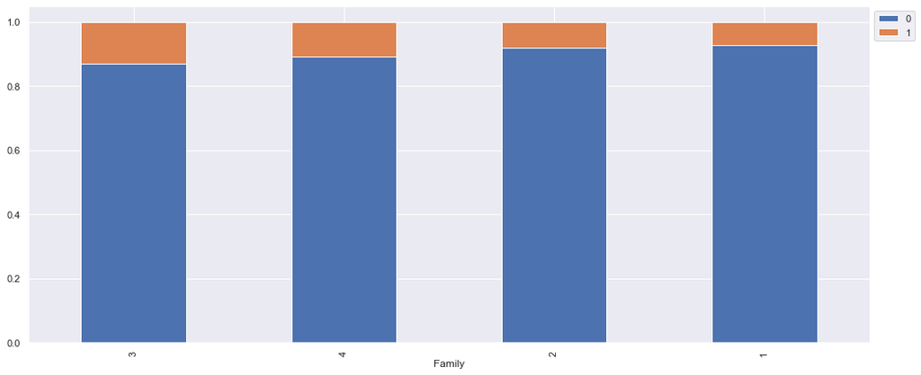

```python
stacked_plot(df.Family)  # to plot stacked barplot of Personal_Loan and Family
```

### Personal_Loan Vs Education

```
Personal_Loan     0    1   All
Education
All            4520  480  5000
3              1296  205  1501
2              1221  182  1403
1              2003   93  2096
------------------------------------------------------------------------------------------------------------------------
```

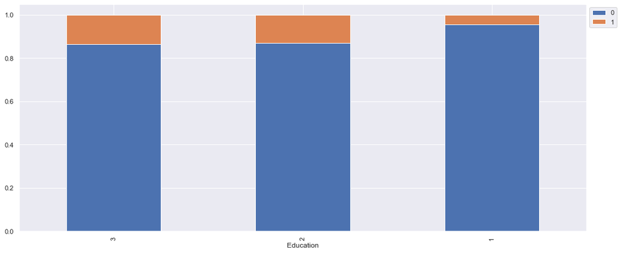

```python
stacked_plot(df.Education)  # to plot stacked barplot of Personal_Loan and Education
```

#### Observation: That highest number of customers that took personal loan have Advanced/Professional Education while the least number are Undergraduates

### Personal_Loan Vs Securities_Account

```
Personal_Loan          0    1   All
Securities_Account
All                 4520  480  5000
0                   4058  420  4478
1                    462   60   522
------------------------------------------------------------------------------------------------------------------------
```

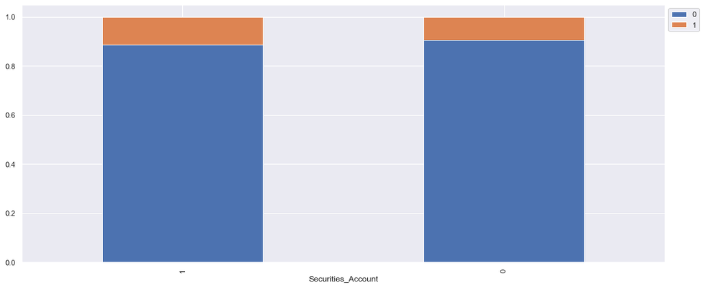

```python
stacked_plot(
    df.Securities_Account
)  # to plot stacked barplot of Personal_Loan and Securities_Account
```

#### Observation: Most customers who took personal loan do not have securities account. However, about 11% of customers that have securities account took personal loan

### Personal_Loan Vs CD_Account

```
Personal_Loan     0    1   All
CD_Account
All            4520  480  5000
0              4358  340  4698
1               162  140   302
------------------------------------------------------------------------------------------------------------------------
```

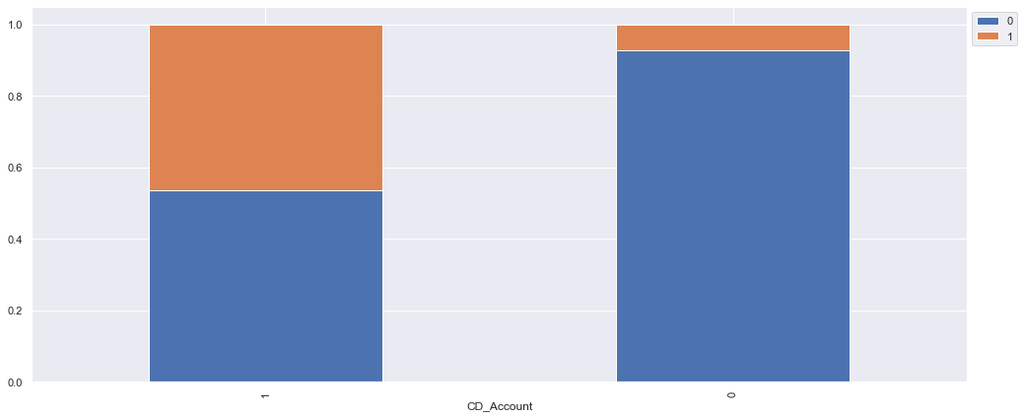

```python
stacked_plot(df.CD_Account)  # to plot stacked barplot of Personal_Loan and CD_Account
```

#### Observation: Most customers who took personal loan do not have certificate of deposit account. However, about 46% of customers that have certificate of deposit account took personal loan which is a better conversion rate to asset customer.

### Personal_Loan Vs Online

```
Personal_Loan     0    1   All
Online
All            4520  480  5000
1              2693  291  2984
0              1827  189  2016
------------------------------------------------------------------------------------------------------------------------
```

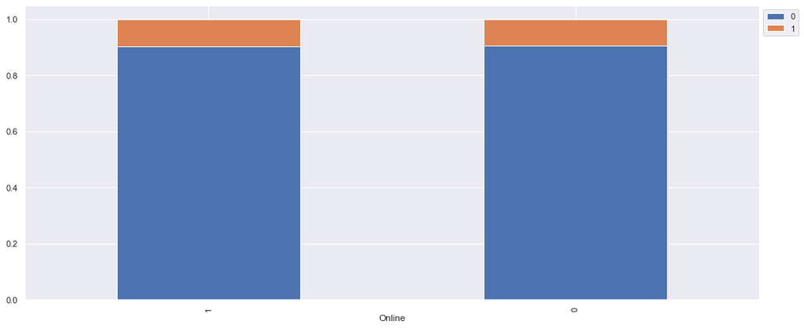

```python
stacked_plot(df.Online)  # to plot stacked barplot of Personal_Loan and Online
```

#### Observation: Most customers that took personal loan are also enjoying internet banking facilities.

### Personal_Loan Vs CreditCard

```
Personal_Loan     0    1   All
CreditCard
All            4520  480  5000
0              3193  337  3530
1              1327  143  1470
------------------------------------------------------------------------------------------------------------------------
```

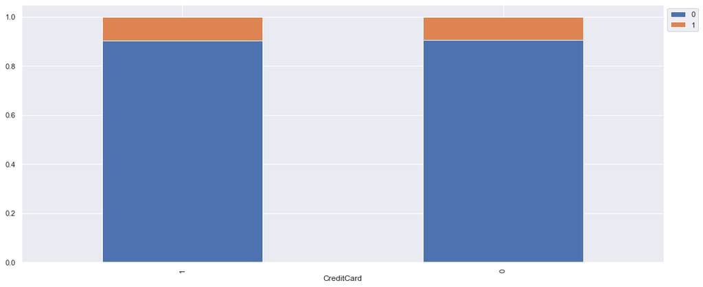

```python
stacked_plot(df.CreditCard)  # to plot stacked barplot of Personal_Loan and CreditCard
```

#### Observation: Most customers who took personal loan do not have any other bank's credit card. However, about 10% of the customers with other bank's credit cards took personal loans at All Life Bank

### Personal_Loan Vs county

```
Personal_Loan        0    1   All
county
All               4520  480  5000
Los Angeles        984  111  1095
Santa Clara        492   71   563
San Diego          509   59   568
Alameda            456   44   500
Orange             309   30   339
San Francisco      238   19   257
Monterey           113   15   128
Sacramento         169   15   184
Contra Costa        73   12    85
San Mateo          192   12   204
Ventura            103   11   114
Santa Barbara      143   11   154
Yolo               122    8   130
Santa Cruz          60    8    68
Kern                47    7    54
Sonoma              22    6    28
Marin               48    6    54
Riverside           50    6    56
San Luis Obispo     28    5    33
Unknown             31    3    34
Shasta              15    3    18
Solano              30    3    33
San Bernardino      98    3   101
Butte               17    2    19
Placer              22    2    24
Fresno              24    2    26
Humboldt            30    2    32
San Joaquin         12    1    13
El Dorado           16    1    17
Stanislaus          14    1    15
Mendocino            7    1     8
Imperial             3    0     3
San Benito          14    0    14
Siskiyou             7    0     7
Napa                 3    0     3
Merced               4    0     4
Trinity              4    0     4
Tuolumne             7    0     7
Lake                 4    0     4
------------------------------------------------------------------------------------------------------------------------
```

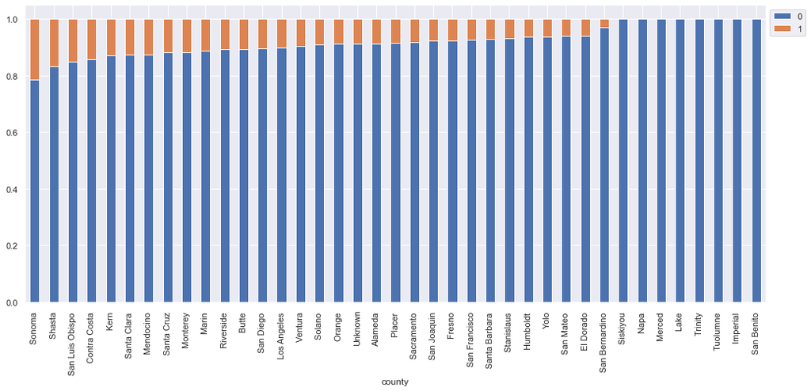

```python
stacked_plot(df.county)  # to plot stacked barplot of Personal_Loan and county
```

#### Observation: Most of the customers that took personal loan live in Los Angeles, Santa Clara, and San Diego. However, Customers from Sonoma county have the highest probability(21%) of taking personal loan

## Treating the Outliers

```python
# Defining the function to clip outliers within the lower and upper whiskers limits
def treat_outliers(data, col):

    Q1 = data[col].quantile(0.25)  # 25th quantile
    Q3 = data[col].quantile(0.75)  # 75th quantile
    IQR = Q3 - Q1
    Lower_Whisker = Q1 - 1.5 * IQR
    Upper_Whisker = Q3 + 1.5 * IQR
    data[col] = np.clip(
        data[col], Lower_Whisker, Upper_Whisker
    )  # all the values smaller than Lower_Whisker will be assigned value of Lower_whisker
    # and all the values above upper_whishker will be assigned value of upper_Whisker
    return data


def treat_outliers_all(data, col_list):

    for c in col_list:
        data = treat_outliers(df, c)

    return data
```

```python
numerical_col = df.select_dtypes(
    include=np.number
).columns.tolist()  # getting list of numerical columns


# Columns to be exempted from outliers treatment
unwanted = {
    "Personal_Loan",
    "Family",
    "Education",
    "Securities_Account",
    "CD_Account",
    "Online",
    "CreditCard",
}  # All these columns aside 'Family' contains intergers that refer to classes. They are more categorical in definition.

numerical_col = [ele for ele in numerical_col if ele not in unwanted]
data = treat_outliers_all(
    df, numerical_col
)  # to apply the outlier treatment function to the dataset
```

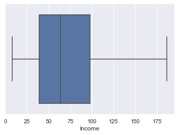

```python
sns.boxplot(df.Income)
# To plot the boxplot of Income again just to confirm the new distribution after outliers treatment
```

#### Observation: No more outliers in the distribution

```python
cat_vars = ["Education", "county"]  # Defining the variables to make categorical

for colname in cat_vars:
    df[colname] = df[colname].astype("category")  # To make the variables catogorical

df.info()
```

```
<class 'pandas.core.frame.DataFrame'>
RangeIndex: 5000 entries, 0 to 4999
Data columns (total 12 columns):
 #   Column              Non-Null Count  Dtype
---  ------              --------------  -----
 0   Age                 5000 non-null   int64
 1   Income              5000 non-null   float64
 2   Family              5000 non-null   int64
 3   CCAvg               5000 non-null   float64
 4   Education           5000 non-null   category
 5   Mortgage            5000 non-null   float64
 6   Personal_Loan       5000 non-null   int64
 7   Securities_Account  5000 non-null   int64
 8   CD_Account          5000 non-null   int64
 9   Online              5000 non-null   int64
 10  CreditCard          5000 non-null   int64
 11  county              5000 non-null   category
dtypes: category(2), float64(3), int64(7)
memory usage: 402.0 KB
```

#### Observation: Education and county are now categorical variables. Personal_Loan,Securities_Account,CD_Account,Online and CreditCard are left as int64 data type because they contain binary features

## Logistic Regression Model Building

### Defining the independent and dependent variables

```python
X = df.drop(
    ["Personal_Loan"], axis=1
)  # defining the independent variables to refer to all other variables in the dataset aside 'Personal_Loan'
Y = df["Personal_Loan"]  # defining the dependent variable to be 'Personal_loan'

X = pd.get_dummies(
    X, columns=X.select_dtypes(include=["category"]).columns.tolist(), drop_first=True
)  # To encode the categorical columns in the dataframe and drop the first dummy column in each variable

# Splitting data in train and test sets with test size 30%
X_train, X_test, y_train, y_test = train_test_split(
    X, Y, test_size=0.30, random_state=1
)
```

```python
print(
    "Shape of Training set : ", X_train.shape
)  # to print the shape of the training set
print("Shape of test set : ", X_test.shape)  # to print the shape of the test set
print("*" * 30)  # to print a demarcation line
print("Percentage of classes in training set:")
print(
    y_train.value_counts(normalize=True)
)  # to print the percentage of each class in the y_train
print("*" * 30)  # to print a demarcation line
print("Percentage of classes in test set:")
print(
    y_test.value_counts(normalize=True)
)  # to print the percentage of each class in the y_train
```

[output not shown]

#### Observation: The train set contains 3500 rows and 49 columns while the test set contains 1500 rows and 49 columns. However they both contain 91% of 0(No personal loan takers) and 9% of 1(personal loan takers) )

### Model evaluation criterion

### Model can make wrong predictions as:

1. Predicting a customer will take personal loan but actually did not .
2. Predicting a customer will not take personal loan but actually did

### Which case is more important?

- Both the cases are important as: a) If we predict a customer will take personal loan but actually did not take, the time and other resources used in marketing personal loan to that customer will be a waste, thereby contributing to loss of revenue to the bank. b) If we predict a customer will not take personal loan but did take, the bank's marketing department would have excluded such potential loan customer from their target marketing campaign.

### How to reduce this loss of the Bank's revenue i.e need to reduce False Positive?

- `f1_score` should be maximized, greater the f1_score higher the chances of identifying both the classes correctly.

**Fist, we will create two functions to calculate different metrics and confusion matrix.**

```python
# defining a function to compute different metrics to check performance of a classification model built


def model_performance_classification_sklearn_with_threshold(
    model, predictors, target, threshold=0.5
):

    # predicting using the independent variables
    pred_prob = model.predict_proba(predictors)[:, 1]
    pred_thres = pred_prob > threshold
    pred = np.round(pred_thres)

    acc = accuracy_score(target, pred)  # to compute Accuracy
    recall = recall_score(target, pred)  # to compute Recall
    precision = precision_score(target, pred)  # to compute Precision
    f1 = f1_score(target, pred)  # to compute F1-score

    # creating a dataframe of metrics
    df_perf = pd.DataFrame(
        {
            "Accuracy": acc,
            "Recall": recall,
            "Precision": precision,
            "F1": f1,
        },
        index=[0],
    )

    return df_perf
```

```python
# defining a function to plot the confusion_matrix of a classification model built
def confusion_matrix_sklearn_with_threshold(model, predictors, target, threshold=0.5):
    """
    To plot the confusion_matrix, based on the threshold specified, with percentages

    model: classifier
    predictors: independent variables
    target: dependent variable
    threshold: threshold for classifying the observation as class 1
    """
    pred_prob = model.predict_proba(predictors)[:, 1]
    pred_thres = pred_prob > threshold
    y_pred = np.round(pred_thres)

    cm = confusion_matrix(target, y_pred)
    labels = np.asarray(
        [
            ["{0:0.0f}".format(item) + "\n{0:.2%}".format(item / cm.flatten().sum())]
            for item in cm.flatten()
        ]
    ).reshape(2, 2)

    plt.figure(figsize=(6, 4))
    sns.heatmap(cm, annot=labels, fmt="")
    plt.ylabel("True label")
    plt.xlabel("Predicted label")
```

### Fitting the Logistic Regression Model

```python
lg = LogisticRegression(solver="newton-cg", random_state=1)
model = lg.fit(X_train, y_train)  # fitting the logistic regression on the train set
```

### Finding Coefficient

```python
# let us check the coefficients and intercept of the model

coef_df = pd.DataFrame(
    np.append(lg.coef_, lg.intercept_),
    index=X_train.columns.tolist() + ["Intercept"],
    columns=["Coefficients"],
)
coef_df.T
```

|  | Age | Income | Family | CCAvg | Mortgage | Securities_Account | CD_Account | Online | CreditCard | Education_2 | Education_3 | county_Butte | county_Contra Costa | county_El Dorado | county_Fresno | county_Humboldt | county_Imperial | county_Kern | county_Lake | county_Los Angeles | county_Marin | county_Mendocino | county_Merced | county_Monterey | county_Napa | county_Orange | county_Placer | county_Riverside | county_Sacramento | … |
| --- | --- | --- | --- | --- | --- | --- | --- | --- | --- | --- | --- | --- | --- | --- | --- | --- | --- | --- | --- | --- | --- | --- | --- | --- | --- | --- | --- | --- | --- | --- |
| Coefficients | 0.007455 | 0.057243 | 0.700539 | 0.421107 | 0.001395 | -0.758226 | 3.072317 | -0.582856 | -0.89488 | 3.420405 | 3.521416 | -0.154433 | 0.326151 | -0.034949 | -0.073792 | -0.382252 | -0.007331 | 0.740881 | -0.013332 | 0.07171 | 0.419129 | -0.147595 | -0.152526 | 0.021699 | -0.005162 | -0.002273 | 0.565088 | 1.124948 | 0.196324 | … |

### Coefficient interpretations

- Coefficient of Securities_Account,Online, CreditCard, and some counties are negative; increase in these will lead to decrease in chances of a customer taking personal loan.
- Coefficient of Age, Income, Family, CCAvg,Mortgage, CD_Account,all levels of Education, and some counties are positive; increase in these will lead to increase in chances of a customer taking personal loan.

**Odds from coefficients**

```python
# converting coefficients to odds
odds = np.exp(lg.coef_[0])

# finding the percentage change
perc_change_odds = (np.exp(lg.coef_[0]) - 1) * 100


# adding the odds to a dataframe
pd.DataFrame({"Odds": odds, "Change_odd%": perc_change_odds}, index=X_train.columns).T
```

|  | Age | Income | Family | CCAvg | Mortgage | Securities_Account | CD_Account | Online | CreditCard | Education_2 | Education_3 | county_Butte | county_Contra Costa | county_El Dorado | county_Fresno | county_Humboldt | county_Imperial | county_Kern | county_Lake | county_Los Angeles | county_Marin | county_Mendocino | county_Merced | county_Monterey | county_Napa | county_Orange | county_Placer | county_Riverside | county_Sacramento | … |
| --- | --- | --- | --- | --- | --- | --- | --- | --- | --- | --- | --- | --- | --- | --- | --- | --- | --- | --- | --- | --- | --- | --- | --- | --- | --- | --- | --- | --- | --- | --- |
| Odds | 1.007483 | 1.058913 | 2.014838 | 1.523647 | 1.001396 | 0.468497 | 21.591864 | 0.558302 | 0.408657 | 30.581796 | 33.832307 | 0.856901 | 1.385625 | 0.965655 | 0.928865 | 0.682323 | 0.992696 | 2.097782 | 0.986756 | 1.074343 | 1.520636 | 0.862780 | 0.858536 | 1.021937 | 0.994851 | 0.997730 | 1.759603 | 3.080056 | 1.216921 | … |
| Change_odd% | 0.748275 | 5.891305 | 101.483780 | 52.364673 | 0.139639 | -53.150308 | 2059.186388 | -44.169817 | -59.134326 | 2958.179578 | 3283.230713 | -14.309929 | 38.562527 | -3.434535 | -7.113543 | -31.767684 | -0.730434 | 109.778228 | -1.324377 | 7.434348 | 52.063635 | -13.721951 | -14.146383 | 2.193652 | -0.514855 | -0.227038 | 75.960341 | 208.005567 | 21.692091 | … |

#### Checking model performance on training set

```python
log_reg_model_train_perf = model_performance_classification_sklearn_with_threshold(
    lg, X_train, y_train
)  # to check model performance on training set

print("Training performance:")
log_reg_model_train_perf
```

```
Training performance:
```

|  | Accuracy | Recall | Precision | F1 |
| --- | --- | --- | --- | --- |
| 0 | 0.963429 | 0.691843 | 0.898039 | 0.78157 |

#### Observation: The model gave an accuracy of 96% but 78% F1 score

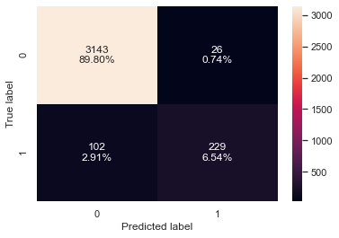

```python
# creating confusion matrix
confusion_matrix_sklearn_with_threshold(lg, X_train, y_train)
```

```python
# Checking performance on test set
log_reg_model_test_perf = model_performance_classification_sklearn_with_threshold(
    lg, X_test, y_test
)

print("Test set performance:")
log_reg_model_test_perf
```

```
Test set performance:
```

|  | Accuracy | Recall | Precision | F1 |
| --- | --- | --- | --- | --- |
| 0 | 0.958667 | 0.644295 | 0.914286 | 0.755906 |

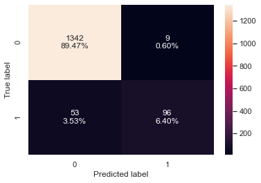

```python
# creating confusion matrix
confusion_matrix_sklearn_with_threshold(lg, X_test, y_test)
```